# Point étape n°5

Auteur·rice

Cefil 2023

**La situation**

Vous êtes chargé d’étude à la Direction Régionale de Nouvelle-Aquitaine. On vous demande de décrire la population, l’emploi et l’accès aux équipements de différents territoires, en illustrant ces thématiques par des indicateurs, des tableaux, des graphiques et des cartes. Ces éléments seront regroupés, au final, dans des documents reproductibles, en vu de créer un atlas régional annualisé.

## 1 Travail préparatoire: vos scripts, vos données.

**À faire**

1. Lancez **RStudio**. Créez un nouveau script que vous sauvegarderez dans le sous-répertoire `Documents/Parcours R/miniprojet`. Attribuez lui le nom `Point_etape_5.R`.
2. Téléchargez le fichier de données `PointEtape4.RData` sur la plateforme Maskaret ainsi que les fonds de carte et copiez les dans un sous-répertoire `donnees/miniprojet/PE5`.

**Aide**

**Séquence 1:**

*Installation de R et RStudio (par le centre logiciel et par téléchargement).*

*Configuration de RStudio, premiers scripts (création, ouverture, modification, enregistrement).*

## 2 Répertoire de travail, packages et imports de fichiers

**À faire**

1. Définissez votre répertoire de travail.
2. Charger les packages *dplyr*, *tidyr*, *ggplot2* et *sf* (installez-les, si besoin)

**Aide**

**Séquence 5:**

*Installation de packages, utilisation. Repérer un package selon ses besoins.*

## 3 Imports des bases

**À faire**

Charger les bases en mémoire en important le fichiers d’environnement `PointEtape4.RData`

**Aide**

**Séquence 5:**

*Imports et exports aux formats rds, RData, SAS, csv, xls.*

## 4 Graphique 1 : Populations régionales et évolutions

L’objectif de cette partie est de reproduire le graphique suivant (`graph_1`)

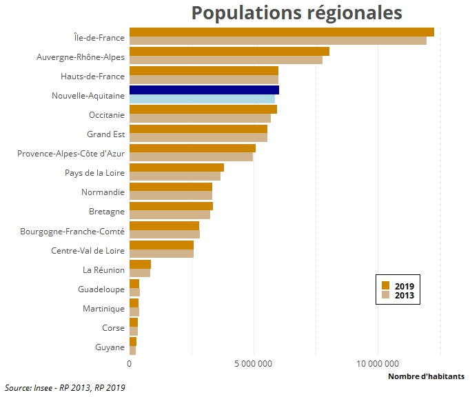

**À faire**

Nous allons utiliser `base_tableaux` pour calculer les indicateurs à représenter. Ce sont les données communales que nous allons agréger au niveau régional.

1. En filtrant Mayotte `REG != "06"`, calculez POP2013 et POP2019, les populations 2013 et 2019 de chaque région. Vous affecterez ce tableau à l’objet `tab_1`.
2. Transformez `tab_1` au format long afin d’obtenir les colonnes `REG`, `LIBREG`, `Annee` et `Population`. (Astuce, utilisez le paramètre `names_prefix = "POP"` afin de ne conserver que l’année dans la colonne `Annee`)
3. Créer `tab_1b` à partir de `tab_1` en modifiant les années `2013` et `2019` en `2013b` et `2019b` pour la région Nouvelle-Aquitaine (`REG == "75"`). Cette manipulation nous permettra de mettre en évidence la région Nouvelle-Aquitaine dans le graphique en lui affectant des couleurs particulières.
4. Créer un vecteurs `couleurs` :  
   `couleurs <- c("tan", "lightblue", "orange3", "darkblue")`

   `names(couleurs) <- c("2013", "2013b", "2019", "2019b")`
5. Créer le diagramme en barres `graph_1`  
   **Astuces** :  
   Pour la gestion des couleurs, utilisez `scale_fill_manual()` en ne spécifiant que `2013` et `2019` pour le paramètre `breaks` et le vecteur `couleurs` pour le paramètre `values`. Il faudra penser à inverser l’ordre des modalités de la légende.  
   Pour les limites de l’axe y, utilisez le paramètre `ylim` dans `coord_flip`() en lui affectant le vecteur `c(0, 1.1 * max(tab_1b$Population))`.

**Aide**

**Séquence 21:**

*Diagrammes en barres*

**Séquence 22:**

*Habillage et mise en forme de graphique*

L’objectif de cette partie est de reproduire le graphique suivant (`graph_2`)

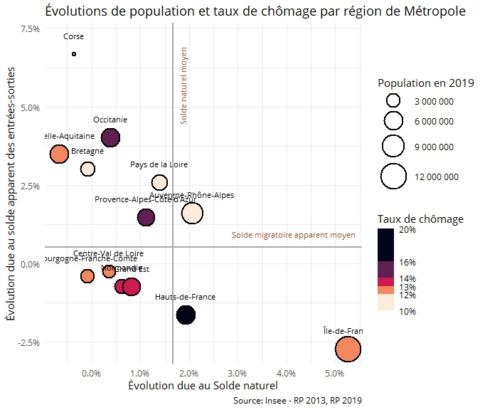

**À faire**

1. À l’aide du verbe `filter()`, ne conservez que les régions de métropole. Effectuez un calcul des indicateurs suivants par région et affectez le à un objet `tab_2`:
   - `CHOM` : nombre de chômeur
   - `ACT` : nombre d’actif
   - `TX_CHOM` : taux de chômage (vous noterez que ce taux sera au sens du RP et non du BIT)
   - `POP2019` : population 2013
   - `POP2013` : population 2019
   - `evol_pop_abs` : évolution absolue de population 2013 - 2019
   - `evol_pop_rel` : évolution absolue de population 2013 - 2019
   - `NAIS` : Naissances entre 2013 et 2019
   - `DECES` : Décès entre 2013 et 2019
   - `SN` : solde naturel (`NAIS - DECES`)
   - `SMA` : solde migratoire apparent (`evol_pop_abs - SN`)
   - `evo_SN` : évolution due au solde naturel `SN / POP2013`,
   - `evo_SMA` : évolution due au solde migratoire apparent `SMA /POP2013`
2. Calculez les même indicateurs pour l’ensemble de la métropole (on pourra refaire le même calcul sans grouper par région ou bien utiliser le tableau `tab_2` en dégroupant et recalculant). Affectez le tableau à un objet `tab_2FM`.
3. Tracez le diagramme `graph_2` avec :
   - une couche `geom_point()` de taille proportionnelle à POP2019, de couleur de remplissage selon le taux de chômage, l’abscisse et l’ordonnée selon les composantes démographiques. Vous choisirez une forme `shape = 21` et une couleur de trait `color = "black"`,
   - une couche de texte `geom_text()` affichant le nom de la région au dessus du rond,
   - une couche `geom_hline()` traçant une droite horizontale d’ordonnée `tab_2FR$evo_SMA`
   - une couche `geom_vline()` traçant une droite verticale d’abscisse `tab_2FR$evo_SN`
   - des annotations `annotate(geom = "text", …)` pour afficher les textes “**Solde naturel moyen”** et **“Solde migratoire apparent moyen”** près des axes.
   - des échelles d’axe x et x en format pourcentage
   - une échelle de couleur de remplissage catégorisé `scale_fill_binned()` avec comme paramètres `type = "viridis", option = "F", direction = -1, breaks = c(0.10, 0.12, 0.13, 0.14 , 0.16), limits = c(0.10, 0.20), guide = guide_coloursteps(even.steps = FALSE, show.limits = TRUE)`
   - une échelle de taille continue avec comme paramètres `range = c(1,12), labels = scales::label_number()`
4. Les titres et un thème `theme_minimal()`

**Aide**

**Séquence 20:**

*Nuages de points*

**Séquence 22:**

*Habillage et mise en forme de graphique*

## 6 Carte 1 : Evolution des populations régionales

L’objectif de cette partie est de reproduire la carte suivante (`carte_1`)

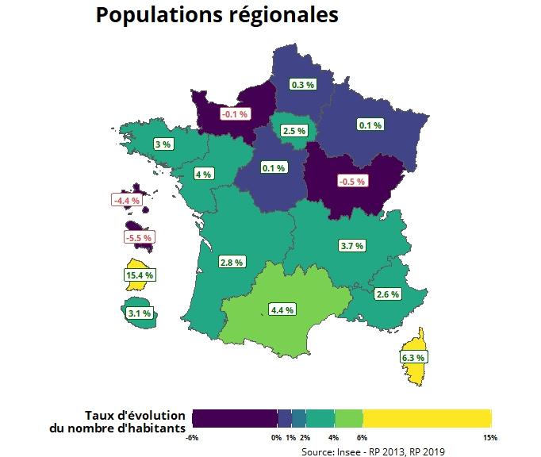

**À faire**

1. Importez le fond de carte `fond_REG` à partir du fichier *fond_reg.gpkg* que vous téléchargerez sur la plateforme.
2. À partir de `tab_1`, vous créerez `tab_1b` en ordonnant par `région` et `Annee`, puis en calculant `evo_abs` l’évolution absolue et `evo_rel` l’évolution relative de population en groupant par région.  
   **Astuce**: vous utiliserez la fonction `lag()` qui permet d’utiliser la ligne précédente dans votre calcul. Pensez à ne conserver que l’année 2019 après ces calculs, en effet, l’année 2013 vous donnera des résultats manquants.
3. Effectuez une jointure entre `tab_1b` et `fond_REG` que vous appellerez `tab_carte_1`. Créez une nouvelle variable `signe` qui prendra la valeur *“pos”* si le la population augmente et *“neg”* si elle diminue.  
   **(IMPORTANT: rajoutez une fonction `st_as_sf()` pour refaire une couche geometry dans le tibble, sinon vous serez obligés de spécifier la projection `geometry = geom` dans la couche `geom_sf()`).**
4. Tracez `carte_1` en plaçant :
   - une couche `geom_sf()` dont la couleur de remplissage est le taux d’évolution du nombre d’habitants
   - une couche d’étiquettes `geom_sf_label()` qui affichera le pourcentage d’évolution, de couleur verte si la population augmente et rouge si elle diminue.
5. Rajoutez :
   - une échelle catégorielle `scale_fill_binned()` avec les paramètres `labels = scales::label_percent()`, `type = "viridis"`, `option = "D"`, `breaks = c(-0.06, 0, 0.01, 0.02, 0.04, 0.06, 0.15)`, `limits = c(-0.06, 0.15)`, `guide = guide_coloursteps(even.steps = FALSE, show.limits = TRUE)`
   - une échelle manuelle pour la couleur des textes : `values = c(pos = "darkgreen" , neg = "indianred3")`
6. Placez la légende de remplissage `fill = colorbar(…)` en bas et horizontale et occultez la légende `color`.
7. Ajoutez les titres, le thème `theme_void()` et les paramètres de thème:
   - `plot.title = element_text(size = 20, face = "bold"),`

     `legend.title = element_text(face = "bold", hjust = 1, vjust = 1),`

     `legend.key.width = unit(2, "cm"),`

     `legend.text = element_text(size = 7, face = "bold")`

**Aide**

**Séquence 23:**

*Les cartes*

## 7 Carte 2 : Taux de chômage par département

L’objectif de cette partie est de reproduire la carte suivante (`carte_2`)

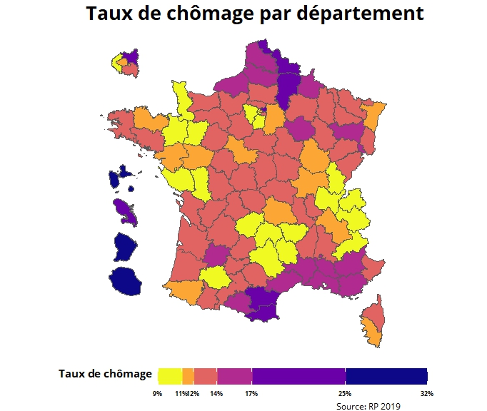

**À faire**

1. Importez le fond de carte `fond_DEP` à partir du fichier *fond_dep_zoomparis.gpkg* que vous téléchargerez sur la plateforme.
2. À partir de `base_tableaux`, vous créerez `tab_2b` en filtrant hors Mayotte (`REG != "06"`) groupant par département pour calculer le nombre de chômeurs `CHOM`, le nombre d’actifs `ACT`, le taux de chômage `TX_CHOM` et `POP2019` la population 2019.
3. Effectuez une jointure entre `tab_2b` et `fond_DEP` que vous appellerez `tab_carte_2`.  
   **(IMPORTANT: rajoutez une fonction `st_as_sf()` pour refaire une couche geometry dans le tibble, sinon vous serez obligés de spécifier la projection `geometry = geom` dans la couche `geom_sf()`).**
4. Tracez `carte_2` en plaçant une couche `geom_sf()` dont la couleur de remplissage est le taux de chômage
5. Rajoutez une échelle catégorielle `scale_fill_binned()` avec les paramètres `labels = scales::label_percent()`, `type = "viridis"`, `option = "C"`, `direction = -1`, `breaks = c(0.09, 0.11, 0.12, 0.14, 0.17, 0.25, 0.32)`, `limits = c(0.09, 0.32)`, `guide = guide_coloursteps(even.steps = FALSE, show.limits = TRUE)`
6. Placez la légende de remplissage `fill = colorbar(…)` en bas et horizontale.
7. Ajoutez les titres, le thème `theme_void()` et les paramètres de thème:
   - `plot.title = element_text(size = 20, face = "bold"),`

     `legend.title = element_text(face = "bold", hjust = 1, vjust = 1),`

     `legend.key.width = unit(2, "cm"),`

     `legend.text = element_text(size = 7, face = "bold")`

**Aide**

**Séquence 23:**

*Les cartes.*

## 8 Exports

**À faire**

1. Exportez l’environnement dans un fichier `exports/PointEtape5.RData`
2. Sauvegardez `graph_1`, `graph_2`, `carte_1` et `carte_2` au format jpg

**Aide**

**Séquence 5:**

*Imports et exports aux formats rds, RData, SAS, csv, xls*

**Séquence 22:**

*Exports de graphiques aux formats d’images.*